# IPA_output BE undiff cells vs BE diff

Karol

2020-06-02

## Introduction

This is output of the standard analysis of IPA. I am printing z-score of activation for transcriptional regulators with corrected p-value below 0.05. In the IPA, I did standard analysis with the only setting changed to Direct Interactions.

IPA: Content version: 51963813 (Release Date: 2020-03-11)

```r
library(ggplot2)
files.dir <- "/home/karolno/Dropbox/Postdoc/2019-12-29_BE2020/Figures/Figure_4/"
location <- paste0(files.dir, "/Data/IPA/")
```

## Figure 4D top

This is analysis of all the genes transcriptional regulators identified between the undifferentiated and differententiated cells of BE. Only IPA data.

Content version: 49932394 (Release Date: 2019-11-14)

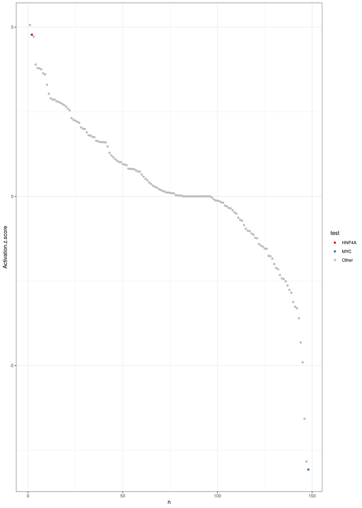

```r
# Read data
all.data <- read.delim(file = paste0(location, "/IPA_S7_BE_DiffvUndiff_upstream.txt"),
    skip = 2)
# Calc log of p-values
all.data$logp <- -log10(all.data$p.value.of.overlap)
# all.data$p.adj<- p.adjust(all.data$p.value.of.overlap, method = 'BH')
# all.data$logq<- -log10(all.data$p.adj)
all.data$logq <- -log10(all.data$B.H.corrected.p.value)


all.data <- all.data[rev(order(all.data$Activation.z.score)), ]
all.data$no.genes <- sapply(as.character(all.data$Target.Molecules.in.Dataset), function(x) {
    length(unlist(strsplit(x, split = ",")))
})

type = "transcription regulator"
max = 20
data.tmp <- all.data[all.data$Molecule.Type == type, ]
data.tmp$Activation.z.score[is.na(data.tmp$Activation.z.score)] <- 0

data.tmp <- data.tmp[rev(order(data.tmp$Activation.z.score)), ]
# keep only data with corrected p-value below 0.05
data.tmp <- data.tmp[data.tmp$B.H.corrected.p.value < 0.05, ]
# data.tmp<-data.tmp[abs(data.tmp$Activation.z.score)>1,]


data.tmp$test <- "Other"
data.tmp$test[lapply(data.tmp$Upstream.Regulator, function(x) grep(pattern = "MYC\\b",
    x, perl = TRUE)) > 0] <- "MYC"
data.tmp$test[lapply(data.tmp$Upstream.Regulator, function(x) grep(pattern = "HNF4",
    x)) > 0] <- "HNF4A"


data.tmp$n <- 1:nrow(data.tmp)


p <- ggplot(data.tmp, aes(y = Activation.z.score, x = n, color = test)) + geom_point() +
    scale_color_manual(values = c("#E41A1C", "#377EB8", "grey")) + theme_bw()

p
```

```r
ggsave(plot = p, file = paste0(files.dir, "./Figure_4DTop.pdf"), width = 7, height = 6,
    useDingbats = FALSE)
```

## Figure 4D bottom

Here I am using data from GSEA. GSEA software version 4.0.3, C3 TF Database version 7.1

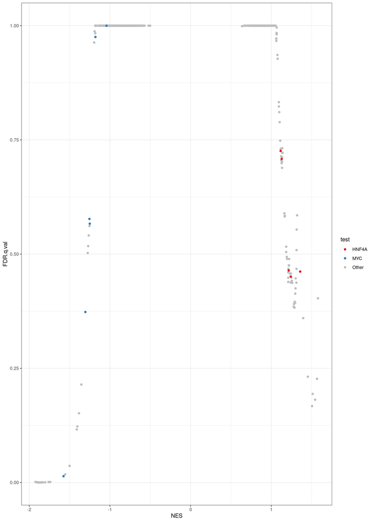

```r
# Read data
GSEA.dir <- "/home/karolno/Dropbox/Postdoc/2019-12-29_BE2020/Figures/Figure_4/Data/GSEA/BE_undiffvsdiff_C3TFmotifs.GseaPreranked.1585565155707/"

all.data <- read.delim(file = paste0(GSEA.dir, "gsea_report_for_na_pos_1585565155707.xls"))
all.data <- rbind(all.data, read.delim(file = paste0(GSEA.dir, "/gsea_report_for_na_neg_1585565155707.xls")))


all.data$test <- "Other"
all.data$test[lapply(all.data$GS.br..follow.link.to.MSigDB, function(x) grep(pattern = "MYC",
    x)) > 0] <- "MYC"
all.data$test[lapply(all.data$GS.br..follow.link.to.MSigDB, function(x) grep(pattern = "HNF4",
    x)) > 0] <- "HNF4A"

# all.data$test[is.na(all.data$test)]<-FALSE
all.data <- all.data[rev(order(all.data$NES)), ]

all.data$n <- 1:nrow(all.data)
all.data <- all.data[rev(order(all.data$test)), ]

ggplot(all.data, aes(x = NES, y = FDR.q.val, color = test)) + geom_point() + scale_color_manual(values = c("#E41A1C",
    "#377EB8", "grey")) + theme_bw()
```

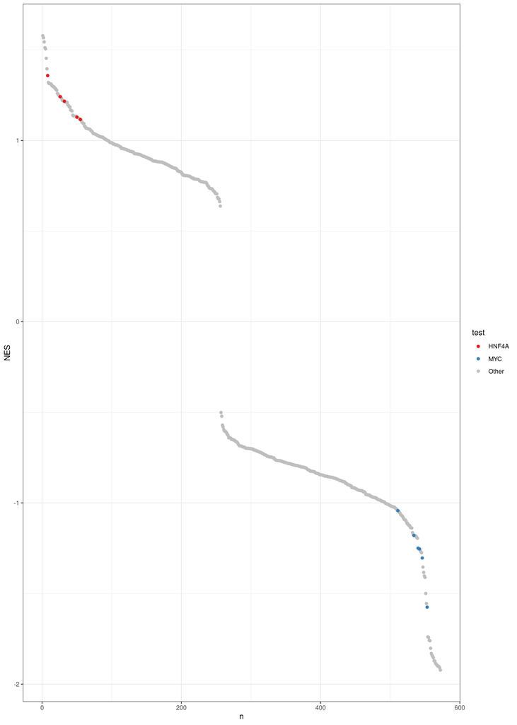

```r
p <- ggplot(all.data, aes(y = NES, x = n, color = test)) + geom_point() + scale_color_manual(values = c("#E41A1C",
    "#377EB8", "grey")) + theme_bw()


p
```

```r
ggsave(plot = p, file = paste0(files.dir, "./Figure_4Dbottom.pdf"), width = 7, height = 6,
    useDingbats = FALSE)
```

## End Matters

To finish get session info: R version 3.6.2 (2019-12-12) Platform: x86_64-redhat-linux-gnu (64-bit) Running under: Fedora 31 (Workstation Edition)

Matrix products: default BLAS/LAPACK: /usr/lib64/R/lib/libRblas.so

locale: [1] LC_CTYPE=en_GB.UTF-8 LC_NUMERIC=C  
[3] LC_TIME=en_GB.UTF-8 LC_COLLATE=en_GB.UTF-8  
[5] LC_MONETARY=en_GB.UTF-8 LC_MESSAGES=en_GB.UTF-8  
[7] LC_PAPER=en_GB.UTF-8 LC_NAME=C  
[9] LC_ADDRESS=C LC_TELEPHONE=C  
[11] LC_MEASUREMENT=en_GB.UTF-8 LC_IDENTIFICATION=C

attached base packages: [1] stats graphics grDevices utils datasets methods base

other attached packages: [1] ggplot2_3.2.1 rmarkdown_2.1

loaded via a namespace (and not attached): [1] Rcpp_1.0.3 knitr_1.28 magrittr_1.5 tidyselect_1.0.0 [5] munsell_0.5.0 colorspace_1.4-1 R6_2.4.1 rlang_0.4.4  
[9] dplyr_0.8.4 stringr_1.4.0 tools_3.6.2 grid_3.6.2  
[13] gtable_0.3.0 xfun_0.12 withr_2.1.2 htmltools_0.4.0 [17] assertthat_0.2.1 yaml_2.2.1 lazyeval_0.2.2 digest_0.6.24  
[21] tibble_2.1.3 lifecycle_0.1.0 crayon_1.3.4 farver_2.0.3  
[25] purrr_0.3.3 formatR_1.7 glue_1.3.1 evaluate_0.14  
[29] labeling_0.3 stringi_1.4.5 compiler_3.6.2 pillar_1.4.3  
[33] scales_1.1.0 pkgconfig_2.0.3